# Working with survey data using the CEOdata package

Xavier Fernández-i-Marín

06/07/2023 - Version 1.3.1.1

When working with survey data there are several issues / strategies to clean and prepare the data that are useful and worth being incorporated to the routines and workflow. This vignette uses the `CEOdata` package to present several examples.

It uses primarily the data retrieved by default using the `CEOdata()` function in its default form, which retrieves the compiled “Barometers” from 2014 onwards.

```r
library(CEOdata)
d <- CEOdata()
```

# Incorporate Tables and Figures

Once you have retrieved the data of the surveys, it is easy to accommodate them to your regular workflow. For instance, to get the overall number of males and females surveyed:

```r
library(dplyr)
library(tidyr)
library(ggplot2)
```

```r
d |>
  count(SEXE)
```

```
## # A tibble: 2 × 2
##   SEXE        n
##   <fct>   <int>
## 1 Masculí 21122
## 2 Femení  22716
```

Or to trace the proportion of females surveyed over time, across barometers:

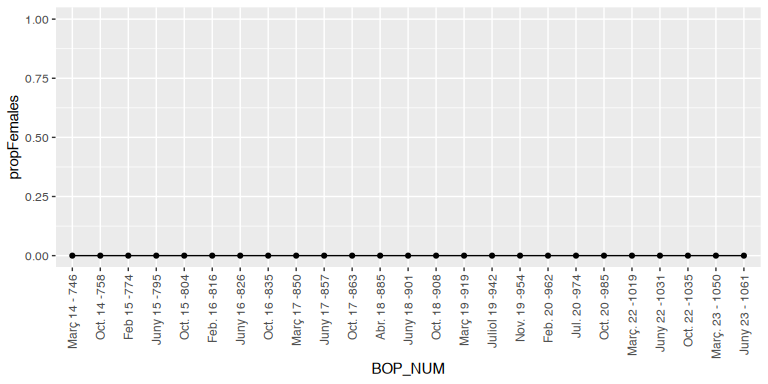

Proportion of females in the different Barometers.

```r
d |>
  group_by(BOP_NUM) |>
  summarize(propFemales = length(which(SEXE == "Dona")) / n()) |>
  ggplot(aes(x = BOP_NUM, y = propFemales, group = 1)) +
  geom_point() +
  geom_line() +
  theme(axis.text.x = element_text(angle = 90, hjust = 1, vjust = 0.5)) +
  expand_limits(y = c(0, 1))
```

# Topics (Tags)

Alternatively, the metadata can also be explored using the different topics (tags, called “Descriptors”) covered as reported by the CEO.

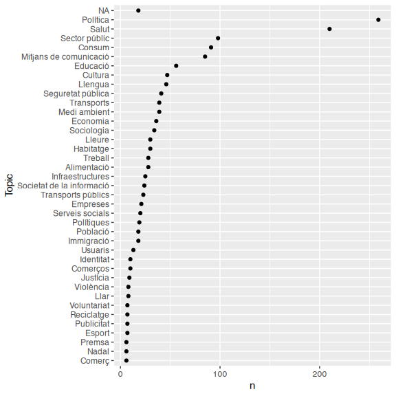

Prevalence of topics covered.

```r
tags <- CEOmeta() |>
  separate_rows(Descriptors, sep = ";") |>
  mutate(tag = factor(stringr::str_trim(Descriptors))) |>
  select(REO, tag)

tags |>
  group_by(tag) |>
  count() |>
  filter(n > 5) |>
  ggplot(aes(x = n, y = reorder(tag, n))) +
    geom_point() +
    ylab("Topic")
```

# Fieldwork

The metadata also provides the option of examining the time periods where there has been fieldwork in quantitative studies, since 2018. In addition, we can distinguish between studies that provide microdata and surveys that don’t.

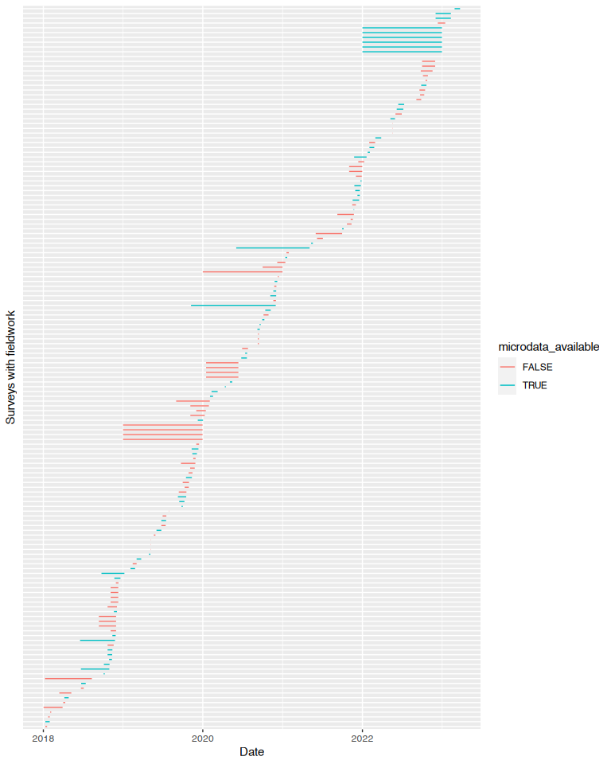

Fieldwork periods.

```r
CEOmeta() |>
  filter(`Dia inici treball de camp` > "2018-01-01") |>
  ggplot(aes(xmin = `Dia inici treball de camp`,
             xmax = `Dia final treball de camp`,
             y = reorder(REO, `Dia final treball de camp`),
             color = microdata_available)) +
  geom_linerange() +
  xlab("Date") + ylab("Surveys with fieldwork") +
  theme(axis.ticks.y = element_blank(), axis.text.y = element_blank())
```

# Arrange and store

Once a dataset has been retrieved from the CEO servers, it is important to clean it and arrange it to one’s individual preferences, and store the result in an R object.

The following example, for instance, process several variables of the survey, picks them and stores the resulting object in a workspace (RData) format.

```r
survey.data <- d |>
  mutate(Female = ifelse(SEXE == "Dona", 1, 0),
         Age = EDAT,
         # Pass NA correctly
         Income = ifelse(INGRESSOS_1_15 %in% c("No ho sap", "No contesta"),
                         NA,
                         INGRESSOS_1_15),
         Date = Data,
         # Reorganize factor labels
         `Place of birth` = factor(case_when(
            LLOC_NAIX == "Catalunya" ~ "Catalonia",
            LLOC_NAIX %in% c("No ho sap", "No contesta") ~ as.character(NA),
            TRUE ~ "Outside Catalonia")),
         # Convert into numerical (integer)
         `Interest in politics` = case_when(
            INTERES_POL == "Gens" ~ 0L,
            INTERES_POL == "Poc" ~ 1L,
            INTERES_POL == "Bastant" ~ 2L,
            INTERES_POL == "Molt" ~ 3L,
            TRUE ~ as.integer(NA)),
         # Convert into numeric (double) and properly address missing values
         `Satisfaction with democracy` = ifelse(
            SATIS_DEMOCRACIA %in% c("No ho sap", "No contesta"),
            NA,
            as.numeric(SATIS_DEMOCRACIA))) |>
  # Center income to the median
  mutate(Income = Income - median(Income, na.rm = TRUE)) |>
  # Pick only specific variables
  select(Date, Female, Age, Income,
         `Place of birth`, `Interest in politics`,
         `Satisfaction with democracy`)
```

Finally, this can be stored for further analysis (hence, without the need to download and arrange the data again) in an R’s native format:

```r
save(survey.data, file = "my_cleaned_dataset.RData")
```

# Descriptive summary

There are several packages that construct convenient tables with the descriptive summary of a dataset. For example, using the `vtable` package to produce a table with descriptive statistics.

```r
library(vtable)
st(survey.data)
```

Summary Statistics

| Variable | N | Mean | Std. Dev. | Min | Pctl. 25 | Pctl. 75 | Max |
| --- | --- | --- | --- | --- | --- | --- | --- |
| Female | 43838 | 0 | 0 | 0 | 0 | 0 | 0 |
| Age | 43838 | 51 | 18 | 18 | 37 | 65 | 99 |
| Income | 32184 | -0.028 | 2.8 | -7 | -2 | 2 | 7 |
| Place of birth | 43836 |  |  |  |  |  |  |
| … Catalonia | 30751 | 70% |  |  |  |  |  |
| … Outside Catalonia | 13085 | 30% |  |  |  |  |  |
| Interest in politics | 33736 | 1.5 | 0.98 | 0 | 1 | 2 | 3 |
| Satisfaction with democracy | 42987 | 3 | 0.74 | 1 | 3 | 4 | 4 |

Or the `compareGroups` that allows to flexibly produce tables that compare descriptive statistics for different groups of individuals.

```r
library(compareGroups)
createTable(compareGroups(Female ~ . -Date, data = survey.data))
```

```
##
## --------Summary descriptives table by 'Female'---------
##
## ___________________________________________________
##                                   0       p.overall
##                                N=43838
## ¯¯¯¯¯¯¯¯¯¯¯¯¯¯¯¯¯¯¯¯¯¯¯¯¯¯¯¯¯¯¯¯¯¯¯¯¯¯¯¯¯¯¯¯¯¯¯¯¯¯¯
## Edat                         50.5 (17.8)      .
## Income                      -0.03 (2.81)      .
## Place of birth:                               .
##     Catalonia               30751 (70.2%)
##     Outside Catalonia       13085 (29.8%)
## Interest in politics         1.46 (0.98)      .
## Satisfaction with democracy  3.02 (0.74)      .
## ¯¯¯¯¯¯¯¯¯¯¯¯¯¯¯¯¯¯¯¯¯¯¯¯¯¯¯¯¯¯¯¯¯¯¯¯¯¯¯¯¯¯¯¯¯¯¯¯¯¯¯
```

# Development and acknowledgement

The development of `CEOdata` (track changes, propose improvements, report bugs) can be followed at [github](https://github.com/ceopinio/CEOdata/).

If using the data and the package, please cite and acknowledge properly the CEO and the package, respectively.